# Airbnb

Group 32

10/17/2020

# Introduction, Data, Methods

In this project, we are going to analyse data about Airbnb listings and fit a model to predict the total cost for two people staying 4 nights in an Airbnb in a city. Our data comes from insideairbnb.com; it was originally scraped from airbnb.com.

```r
# Load data
listings <- vroom("http://data.insideairbnb.com/belgium/bru/brussels/2020-06-15/data/listings.csv.gz")
```

Some important variables are as follows:

- `price` : cost per night
- `cleaning_fee`: cleaning fee
- `extra_people`: charge for having 1 more person
- `property_type`: type of accommocation (House, Apartment, etc.)
- `room_type`: Entire home, Private room, Shared room
- `number_of_reviews`: Total number of reviews for the listing
- `review_scores_rating`: Average review score (0-100)
- `longtitude`, `latitude`: geographical coordinates to help us locate the listing
- `neighbourhood*`: three variables on a few major neighbourboods in each city

Firstly, we start with a map of Brussels, and overlay all Airbnb coordinates to get an overview of the spatial distribution of Airbnb rentals. For this visualization, we use `leaflet` package, which includes a variety of tools for interactive maps.

```r
leaflet(data = filter(listings,minimum_nights<=4)) %>%
  addProviderTiles("OpenStreetMap.Mapnik") %>%
  addCircleMarkers(lng = ~longitude,
                   lat = ~latitude,
                   radius = 1,
                   fillColor = "blue",
                   fillOpacity = 0.4,
                   popup = ~listing_url,
                   label = ~property_type)
```

[interactive chart not shown]

# Data Wrangling and Exploratory Data Analysis (EDA)

## Data Wrangling

Some of the price data (`price`, `cleaning_fee`, `extra_people`) is given as a character string. Since what we want is a quantitative variable, we need to make sure it is stored as numeric data `num` in the dataframe. To do so, we will first use `readr::parse_number()` which drops any non-numeric characters before or after the first number.

```r
listings <- listings %>%
  mutate(price = parse_number(price)) %>%
  mutate(cleaning_fee= parse_number(cleaning_fee)) %>%
  mutate(extra_people= parse_number(extra_people))

typeof(listings$price)
```

```
## [1] "double"
```

```r
typeof(listings$cleaning_fee)
```

```
## [1] "double"
```

```r
typeof(listings$extra_people)
```

```
## [1] "double"
```

We then impute the missing values of `cleaning_fee` with an appropriate numeric value.

```r
listings <- listings %>%
  mutate(cleaning_fee = case_when(
    is.na(cleaning_fee) ~ 0,
    TRUE ~ cleaning_fee
  ))
```

Next, we look at the variable `property_type`. Since the vast majority of the observations in the data are one of the top four of five property types, we would like to create a simplified version of `property_type` variable that has 5 catergories: the top four categories and `Other`.

```r
listings <- listings %>%
  mutate(prop_type_simplified = case_when(
    property_type %in% c("Apartment","House", "Condominium","Townhouse") ~ property_type,
    TRUE ~ "Other"
  ))
```

Airbnb is most commonly used for travel purposes, i.e., as an alternative to traditional hotels. We only want to include listings in our regression analysis that are intended for travel purposes. We first use `skimr::skim()` to get an overview of `minimum_nights`. Most observations are lower than 4, with some extreme large values. To mitigate the influence of these outliers, we filter the airbnb data so that it only include observations with `minimum_nights<=4`

```r
skim(listings$minimum_nights)
```

Data summary

| Name | listings$minimum_nights |
| --- | --- |
| Number of rows | 8986 |
| Number of columns | 1 |
| _______________________ |  |
| Column type frequency: |  |
| numeric | 1 |
| ________________________ |  |
| Group variables | None |

**Variable type: numeric**

| skim_variable | n_missing | complete_rate | mean | sd | p0 | p25 | p50 | p75 | p100 | hist |
| --- | --- | --- | --- | --- | --- | --- | --- | --- | --- | --- |
| data | 0 | 1 | 7.4 | 29.2 | 1 | 1 | 2 | 3 | 1000 | ▇▁▁▁▁ |

```r
listings <- listings %>%
  filter(minimum_nights <= 4)
```

We drop some variables and only keep some necessary ones in our analysis. We then skim the dataset to see if further data wrangling is required.

```r
listings_selected <- listings %>%
  select("id", "price", "cleaning_fee", "extra_people", "prop_type_simplified", "room_type", "minimum_nights", "guests_included", "number_of_reviews", "review_scores_rating", "longitude", "latitude", "neighbourhood","neighbourhood_cleansed", "listing_url","bathrooms","bedrooms","beds","accommodates","host_is_superhost","is_location_exact","cancellation_policy")

glimpse(listings_selected)
```

```
## Rows: 7,279
## Columns: 22
## $ id                     <dbl> 2352, 2354, 45145, 48180, 71744, 80257, 80320,…
## $ price                  <dbl> 93, 78, 100, 200, 60, 95, 85, 85, 135, 70, 85,…
## $ cleaning_fee           <dbl> 65, 65, 0, 0, 15, 0, 0, 0, 0, 0, 0, 0, 60, 0, …
## $ extra_people           <dbl> 5, 0, 30, 20, 15, 20, 10, 10, 25, 20, 10, 45, …
## $ prop_type_simplified   <chr> "Apartment", "Apartment", "Other", "Apartment"…
## $ room_type              <chr> "Entire home/apt", "Entire home/apt", "Hotel r…
## $ minimum_nights         <dbl> 2, 2, 1, 2, 2, 1, 1, 1, 1, 1, 1, 2, 3, 1, 1, 1…
## $ guests_included        <dbl> 4, 1, 1, 1, 2, 2, 2, 2, 4, 2, 2, 1, 1, 2, 2, 2…
## $ number_of_reviews      <dbl> 15, 2, 3, 0, 12, 4, 59, 6, 48, 25, 33, 3, 1, 4…
## $ review_scores_rating   <dbl> 87, 80, 100, NA, 98, 90, 93, 97, 87, 91, 92, 9…
## $ longitude              <dbl> 4.31, 4.31, 4.37, 4.41, 4.35, 4.34, 4.34, 4.34…
## $ latitude               <dbl> 50.9, 50.9, 50.9, 50.8, 50.9, 50.8, 50.8, 50.8…
## $ neighbourhood          <chr> "Molenbeek-Saint-Jean", "Molenbeek-Saint-Jean"…
## $ neighbourhood_cleansed <chr> "Molenbeek-Saint-Jean", "Molenbeek-Saint-Jean"…
## $ listing_url            <chr> "https://www.airbnb.com/rooms/2352", "https://…
## $ bathrooms              <dbl> 1.0, 1.0, 1.0, 1.5, 1.0, 1.0, 1.0, 1.0, 2.0, 1…
## $ bedrooms               <dbl> 2, 1, 1, 2, 1, 0, 0, 0, 1, 0, 1, 2, 1, 0, 1, 0…
## $ beds                   <dbl> 2, 1, 1, 2, 1, 2, 2, 2, 4, 2, 3, 3, 1, 2, 1, 2…
## $ accommodates           <dbl> 5, 4, 2, 2, 2, 3, 3, 3, 6, 3, 4, 4, 2, 3, 2, 3…
## $ host_is_superhost      <lgl> FALSE, FALSE, FALSE, FALSE, FALSE, FALSE, FALS…
## $ is_location_exact      <lgl> TRUE, TRUE, FALSE, TRUE, TRUE, TRUE, TRUE, TRU…
## $ cancellation_policy    <chr> "strict_14_with_grace_period", "strict_14_with…
```

```r
skim(listings_selected)
```

Data summary

| Name | listings_selected |
| --- | --- |
| Number of rows | 7279 |
| Number of columns | 22 |
| _______________________ |  |
| Column type frequency: |  |
| character | 6 |
| logical | 2 |
| numeric | 14 |
| ________________________ |  |
| Group variables | None |

**Variable type: character**

| skim_variable | n_missing | complete_rate | min | max | empty | n_unique | whitespace |
| --- | --- | --- | --- | --- | --- | --- | --- |
| prop_type_simplified | 0 | 1 | 5 | 11 | 0 | 5 | 0 |
| room_type | 0 | 1 | 10 | 15 | 0 | 4 | 0 |
| neighbourhood | 0 | 1 | 5 | 21 | 0 | 49 | 0 |
| neighbourhood_cleansed | 0 | 1 | 5 | 21 | 0 | 19 | 0 |
| listing_url | 0 | 1 | 33 | 37 | 0 | 7279 | 0 |
| cancellation_policy | 0 | 1 | 8 | 27 | 0 | 5 | 0 |

**Variable type: logical**

| skim_variable | n_missing | complete_rate | mean | count |
| --- | --- | --- | --- | --- |
| host_is_superhost | 3 | 1 | 0.18 | FAL: 5961, TRU: 1315 |
| is_location_exact | 0 | 1 | 0.84 | TRU: 6079, FAL: 1200 |

**Variable type: numeric**

| skim_variable | n_missing | complete_rate | mean | sd | p0 | p25 | p50 | p75 | p100 | hist |
| --- | --- | --- | --- | --- | --- | --- | --- | --- | --- | --- |
| id | 0 | 1.00 | 2.50e+07 | 1.29e+07 | 2352.00 | 1.39e+07 | 2.60e+07 | 3.71e+07 | 4.38e+07 | ▅▅▅▅▇ |
| price | 0 | 1.00 | 7.83e+01 | 1.17e+02 | 0.00 | 4.20e+01 | 6.00e+01 | 8.90e+01 | 7.00e+03 | ▇▁▁▁▁ |
| cleaning_fee | 0 | 1.00 | 1.88e+01 | 2.36e+01 | 0.00 | 0.00e+00 | 1.20e+01 | 3.00e+01 | 5.05e+02 | ▇▁▁▁▁ |
| extra_people | 0 | 1.00 | 7.81e+00 | 1.24e+01 | 0.00 | 0.00e+00 | 0.00e+00 | 1.50e+01 | 2.69e+02 | ▇▁▁▁▁ |
| minimum_nights | 0 | 1.00 | 1.87e+00 | 8.90e-01 | 1.00 | 1.00e+00 | 2.00e+00 | 2.00e+00 | 4.00e+00 | ▇▇▁▃▁ |
| guests_included | 0 | 1.00 | 1.53e+00 | 1.05e+00 | 1.00 | 1.00e+00 | 1.00e+00 | 2.00e+00 | 1.60e+01 | ▇▁▁▁▁ |
| number_of_reviews | 0 | 1.00 | 3.45e+01 | 6.62e+01 | 0.00 | 2.00e+00 | 9.00e+00 | 3.40e+01 | 7.66e+02 | ▇▁▁▁▁ |
| review_scores_rating | 1223 | 0.83 | 9.27e+01 | 8.52e+00 | 20.00 | 9.00e+01 | 9.50e+01 | 9.80e+01 | 1.00e+02 | ▁▁▁▁▇ |
| longitude | 0 | 1.00 | 4.36e+00 | 3.00e-02 | 4.26 | 4.34e+00 | 4.36e+00 | 4.38e+00 | 4.49e+00 | ▁▆▇▂▁ |
| latitude | 0 | 1.00 | 5.08e+01 | 2.00e-02 | 50.77 | 5.08e+01 | 5.08e+01 | 5.09e+01 | 5.09e+01 | ▁▂▇▃▁ |
| bathrooms | 3 | 1.00 | 1.18e+00 | 5.80e-01 | 0.00 | 1.00e+00 | 1.00e+00 | 1.00e+00 | 3.00e+01 | ▇▁▁▁▁ |
| bedrooms | 27 | 1.00 | 1.21e+00 | 8.60e-01 | 0.00 | 1.00e+00 | 1.00e+00 | 1.00e+00 | 3.00e+01 | ▇▁▁▁▁ |
| beds | 77 | 0.99 | 1.74e+00 | 1.33e+00 | 0.00 | 1.00e+00 | 1.00e+00 | 2.00e+00 | 3.10e+01 | ▇▁▁▁▁ |
| accommodates | 0 | 1.00 | 3.08e+00 | 1.77e+00 | 1.00 | 2.00e+00 | 2.00e+00 | 4.00e+00 | 1.60e+01 | ▇▁▁▁▁ |

As we can see, `review_scores_rating`, `bathrooms`, `bedrooms`, and `beds` still have missing values. We will replace missing values of `review_scores_rating` with average `review_scores_rating`. As for `bathrooms`, `bedrooms`, and `beds`, we drop missing values. Price variables (`price`,`cleaning_fee`,`extra_people`) obviously skew to the right. When putting these values into our regression model, we will take logrithm.

```r
temp=mean(listings_selected$review_scores_rating,na.rm=TRUE)

listings_selected<-listings_selected %>%
  mutate(review_scores_rating=case_when(
    is.na(review_scores_rating) ~ temp,
    TRUE ~ review_scores_rating
  ))

listings_selected<-listings_selected %>%
  drop_na(bathrooms,bedrooms,beds)
```

Up to now, we have already dealt with missing data and outliers. Next, we are going to create a new variable called `price_4_nights` that uses `price`, `cleaning_fee`, `guests_included`, and `extra_people` to calculate the total cost for two people to stay at the Airbnb property for 4 nights. This is the variable Y we want to explain.

```r
listings_selected <- listings_selected %>%
  mutate(price_4_nights = case_when(
    guests_included >= 2 ~ (cleaning_fee + price)*4,
    TRUE ~ (cleaning_fee + price + extra_people)*4))
```

## Exploratory Data Analysis (EDA)

### General Overview

```r
glimpse(listings_selected)
```

```
## Rows: 7,186
## Columns: 23
## $ id                     <dbl> 2352, 2354, 45145, 48180, 71744, 80257, 80320,…
## $ price                  <dbl> 93, 78, 100, 200, 60, 95, 85, 85, 135, 70, 85,…
## $ cleaning_fee           <dbl> 65, 65, 0, 0, 15, 0, 0, 0, 0, 0, 0, 0, 60, 0, …
## $ extra_people           <dbl> 5, 0, 30, 20, 15, 20, 10, 10, 25, 20, 10, 45, …
## $ prop_type_simplified   <chr> "Apartment", "Apartment", "Other", "Apartment"…
## $ room_type              <chr> "Entire home/apt", "Entire home/apt", "Hotel r…
## $ minimum_nights         <dbl> 2, 2, 1, 2, 2, 1, 1, 1, 1, 1, 1, 2, 3, 1, 1, 1…
## $ guests_included        <dbl> 4, 1, 1, 1, 2, 2, 2, 2, 4, 2, 2, 1, 1, 2, 2, 2…
## $ number_of_reviews      <dbl> 15, 2, 3, 0, 12, 4, 59, 6, 48, 25, 33, 3, 1, 4…
## $ review_scores_rating   <dbl> 87.0, 80.0, 100.0, 92.7, 98.0, 90.0, 93.0, 97.…
## $ longitude              <dbl> 4.31, 4.31, 4.37, 4.41, 4.35, 4.34, 4.34, 4.34…
## $ latitude               <dbl> 50.9, 50.9, 50.9, 50.8, 50.9, 50.8, 50.8, 50.8…
## $ neighbourhood          <chr> "Molenbeek-Saint-Jean", "Molenbeek-Saint-Jean"…
## $ neighbourhood_cleansed <chr> "Molenbeek-Saint-Jean", "Molenbeek-Saint-Jean"…
## $ listing_url            <chr> "https://www.airbnb.com/rooms/2352", "https://…
## $ bathrooms              <dbl> 1.0, 1.0, 1.0, 1.5, 1.0, 1.0, 1.0, 1.0, 2.0, 1…
## $ bedrooms               <dbl> 2, 1, 1, 2, 1, 0, 0, 0, 1, 0, 1, 2, 1, 0, 1, 0…
## $ beds                   <dbl> 2, 1, 1, 2, 1, 2, 2, 2, 4, 2, 3, 3, 1, 2, 1, 2…
## $ accommodates           <dbl> 5, 4, 2, 2, 2, 3, 3, 3, 6, 3, 4, 4, 2, 3, 2, 3…
## $ host_is_superhost      <lgl> FALSE, FALSE, FALSE, FALSE, FALSE, FALSE, FALS…
## $ is_location_exact      <lgl> TRUE, TRUE, FALSE, TRUE, TRUE, TRUE, TRUE, TRU…
## $ cancellation_policy    <chr> "strict_14_with_grace_period", "strict_14_with…
## $ price_4_nights         <dbl> 632, 572, 520, 880, 300, 380, 340, 340, 540, 2…
```

```r
skim(listings_selected)
```

Data summary

| Name | listings_selected |
| --- | --- |
| Number of rows | 7186 |
| Number of columns | 23 |
| _______________________ |  |
| Column type frequency: |  |
| character | 6 |
| logical | 2 |
| numeric | 15 |
| ________________________ |  |
| Group variables | None |

**Variable type: character**

| skim_variable | n_missing | complete_rate | min | max | empty | n_unique | whitespace |
| --- | --- | --- | --- | --- | --- | --- | --- |
| prop_type_simplified | 0 | 1 | 5 | 11 | 0 | 5 | 0 |
| room_type | 0 | 1 | 10 | 15 | 0 | 4 | 0 |
| neighbourhood | 0 | 1 | 5 | 21 | 0 | 49 | 0 |
| neighbourhood_cleansed | 0 | 1 | 5 | 21 | 0 | 19 | 0 |
| listing_url | 0 | 1 | 33 | 37 | 0 | 7186 | 0 |
| cancellation_policy | 0 | 1 | 8 | 27 | 0 | 5 | 0 |

**Variable type: logical**

| skim_variable | n_missing | complete_rate | mean | count |
| --- | --- | --- | --- | --- |
| host_is_superhost | 3 | 1 | 0.18 | FAL: 5870, TRU: 1313 |
| is_location_exact | 0 | 1 | 0.84 | TRU: 6006, FAL: 1180 |

**Variable type: numeric**

| skim_variable | n_missing | complete_rate | mean | sd | p0 | p25 | p50 | p75 | p100 | hist |
| --- | --- | --- | --- | --- | --- | --- | --- | --- | --- | --- |
| id | 0 | 1 | 2.48e+07 | 1.28e+07 | 2352.00 | 1.38e+07 | 2.58e+07 | 3.68e+07 | 4.38e+07 | ▅▅▅▅▇ |
| price | 0 | 1 | 7.86e+01 | 1.17e+02 | 0.00 | 4.20e+01 | 6.00e+01 | 8.90e+01 | 7.00e+03 | ▇▁▁▁▁ |
| cleaning_fee | 0 | 1 | 1.90e+01 | 2.37e+01 | 0.00 | 0.00e+00 | 1.20e+01 | 3.00e+01 | 5.05e+02 | ▇▁▁▁▁ |
| extra_people | 0 | 1 | 7.86e+00 | 1.24e+01 | 0.00 | 0.00e+00 | 0.00e+00 | 1.50e+01 | 2.69e+02 | ▇▁▁▁▁ |
| minimum_nights | 0 | 1 | 1.88e+00 | 8.90e-01 | 1.00 | 1.00e+00 | 2.00e+00 | 2.00e+00 | 4.00e+00 | ▇▇▁▃▁ |
| guests_included | 0 | 1 | 1.53e+00 | 1.06e+00 | 1.00 | 1.00e+00 | 1.00e+00 | 2.00e+00 | 1.60e+01 | ▇▁▁▁▁ |
| number_of_reviews | 0 | 1 | 3.49e+01 | 6.65e+01 | 0.00 | 2.00e+00 | 9.00e+00 | 3.50e+01 | 7.66e+02 | ▇▁▁▁▁ |
| review_scores_rating | 0 | 1 | 9.27e+01 | 7.77e+00 | 20.00 | 9.10e+01 | 9.30e+01 | 9.80e+01 | 1.00e+02 | ▁▁▁▁▇ |
| longitude | 0 | 1 | 4.36e+00 | 3.00e-02 | 4.26 | 4.34e+00 | 4.36e+00 | 4.38e+00 | 4.49e+00 | ▁▆▇▂▁ |
| latitude | 0 | 1 | 5.08e+01 | 2.00e-02 | 50.77 | 5.08e+01 | 5.08e+01 | 5.09e+01 | 5.09e+01 | ▁▂▇▃▁ |
| bathrooms | 0 | 1 | 1.18e+00 | 5.90e-01 | 0.00 | 1.00e+00 | 1.00e+00 | 1.00e+00 | 3.00e+01 | ▇▁▁▁▁ |
| bedrooms | 0 | 1 | 1.22e+00 | 8.50e-01 | 0.00 | 1.00e+00 | 1.00e+00 | 1.00e+00 | 3.00e+01 | ▇▁▁▁▁ |
| beds | 0 | 1 | 1.74e+00 | 1.32e+00 | 0.00 | 1.00e+00 | 1.00e+00 | 2.00e+00 | 3.10e+01 | ▇▁▁▁▁ |
| accommodates | 0 | 1 | 3.08e+00 | 1.77e+00 | 1.00 | 2.00e+00 | 2.00e+00 | 4.00e+00 | 1.60e+01 | ▇▁▁▁▁ |
| price_4_nights | 0 | 1 | 4.01e+02 | 4.95e+02 | 36.00 | 2.20e+02 | 3.20e+02 | 4.60e+02 | 2.80e+04 | ▇▁▁▁▁ |

### Distribution of Price

```r
# A general overview
mosaic::favstats(listings_selected$price_4_nights)
```

| min | Q1 | median | Q3 | max | mean | sd | n | missing |
| --- | --- | --- | --- | --- | --- | --- | --- | --- |
| 36 | 220 | 320 | 460 | 2.8e+04 | 401 | 495 | 7186 | 0 |

We take logrithm of `price_4_nights` and create the density plot. As we can see, the logrithm of price is more like a normal distribution. In our analysis, we will use log(price) as the variable Y to explain.

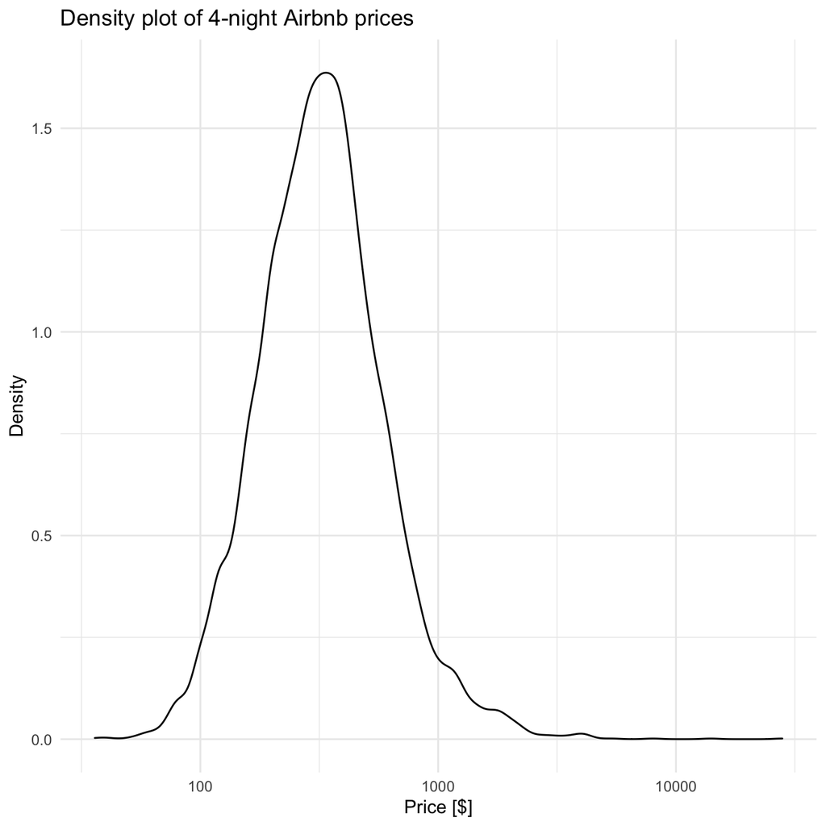

```r
# Create the density plot
ggplot(listings_selected,aes(x=price_4_nights))+
  geom_density(aes(x=price_4_nights))+
  scale_x_log10()+
  labs(title="Density plot of 4-night Airbnb prices",
       x="Price [$]",
       y="Density")+
  theme_minimal()
```

### Review Scores Rating

```r
# A general overview
mosaic::favstats(listings_selected$review_scores_rating)
```

| min | Q1 | median | Q3 | max | mean | sd | n | missing |
| --- | --- | --- | --- | --- | --- | --- | --- | --- |
| 20 | 91 | 93 | 98 | 100 | 92.7 | 7.77 | 7186 | 0 |

We are also interested whether there’s relationship between number of reviews and review scores rating. We divide number of reviews into 4 quartiles and create the boxplot of `review_scores_rating` for each quartile.

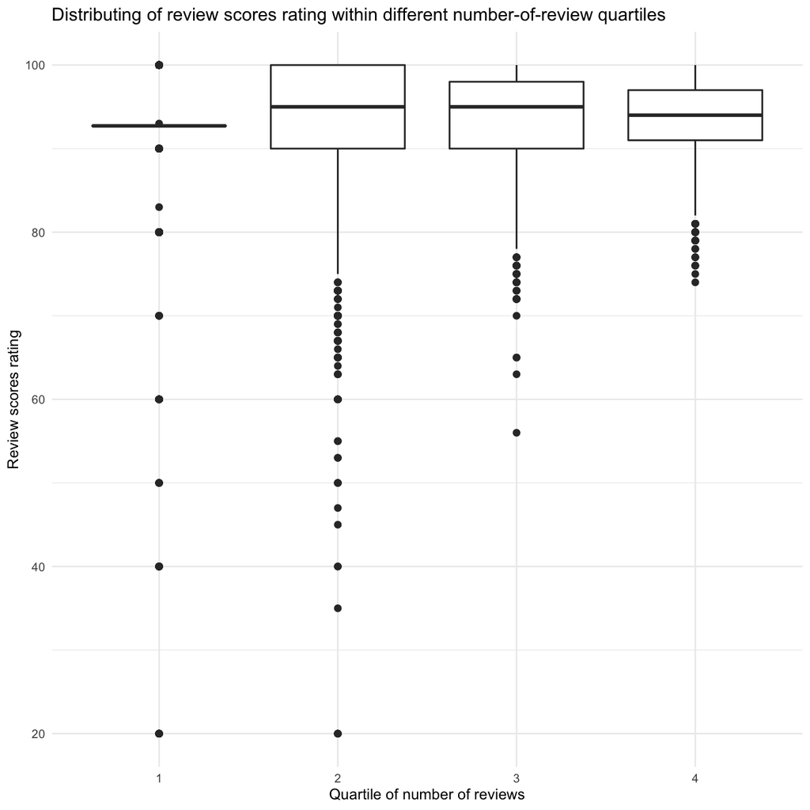

```r
# Divide `number_of_reviews` into 4 quartiles
review_groups <- listings_selected %>%
  mutate(consolidated_ratings_numbers = ntile( number_of_reviews, 4 ))

# Convert into factor
review_groups$consolidated_ratings_numbers <- as.factor(review_groups$consolidated_ratings_numbers)

# Create the boxplot of `review_scores_rating` for each quartile
ggplot(review_groups, aes(x = consolidated_ratings_numbers, y = review_scores_rating)) +
  geom_boxplot()+
  labs(title="Distributing of review scores rating within different number-of-review quartiles",
       x="Quartile of number of reviews",
       y="Review scores rating")+
  theme_minimal(base_size=9)
```

### Correlation Between Price and Scores Rating

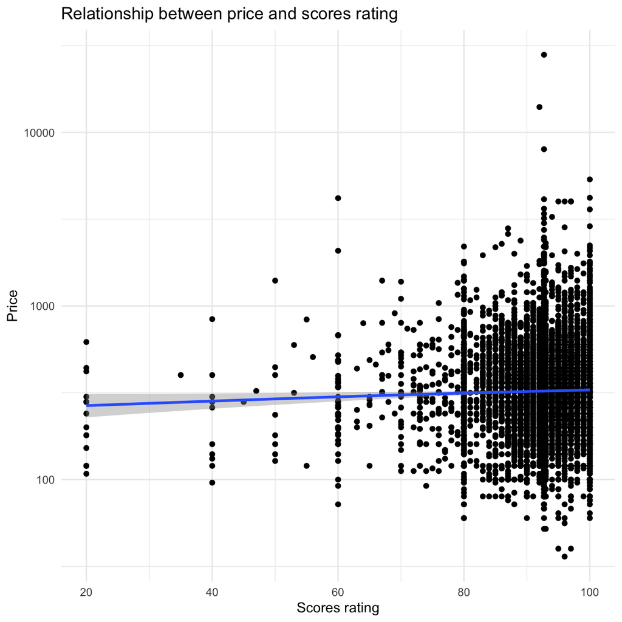

```r
listings_selected %>%
  ggplot(aes(x=review_scores_rating,y=price_4_nights))+
  geom_point()+
  scale_y_log10()+
  geom_smooth()+
  labs(title="Relationship between price and scores rating",
       x="Scores rating",
       y="Price")+
  theme_minimal()
```

As we can see, there’s no clear relationship between price and scores rating.

### Correlation Between Price and Size of House

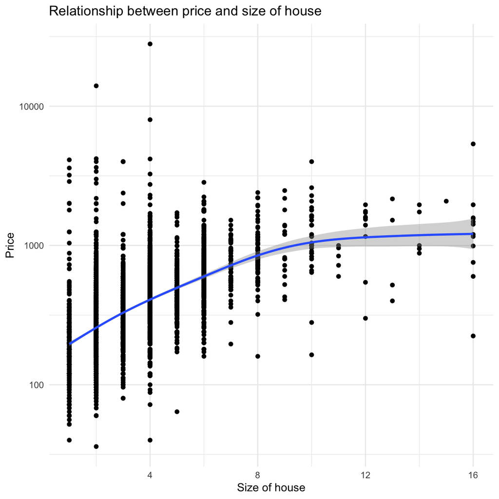

```r
ggplot(listings_selected,aes(x=accommodates,y=price_4_nights))+
  geom_point()+
  geom_smooth()+
  scale_y_log10()+
  labs(title="Relationship between price and size of house",
       x="Size of house",
       y="Price")+
  theme_minimal()
```

It seems that the larger the house, the higher the cost.

# Regression Analysis

In this section, we are going to present our regression analysis. For the target variable Y, we will use the logrithm of the cost for two people to stay at an Airbnb location for four nights.

## Model 1

Model 1 uses following explanatory variables: `prop_type_simplified`, `number_of_reviews`, and `review_scores_rating`. Since `number_of_reviews` is also potentially unbounded and obviously skews right, we also take the logrithm for it.

```r
listings_selected<-listings_selected %>%
  mutate(log_numberofreview=log(1+number_of_reviews))
```

```r
model1 <- lm(log(price_4_nights) ~ prop_type_simplified+log_numberofreview+review_scores_rating,
             data=listings_selected)

summary(model1)
```

```
##
## Call:
## lm(formula = log(price_4_nights) ~ prop_type_simplified + log_numberofreview +
##     review_scores_rating, data = listings_selected)
##
## Residuals:
##    Min     1Q Median     3Q    Max
## -2.181 -0.395 -0.013  0.346  4.172
##
## Coefficients:
##                                  Estimate Std. Error t value Pr(>|t|)
## (Intercept)                      5.444816   0.084899   64.13  < 2e-16 ***
## prop_type_simplifiedCondominium  0.078874   0.035023    2.25  0.02435 *
## prop_type_simplifiedHouse       -0.099920   0.024816   -4.03  5.7e-05 ***
## prop_type_simplifiedOther        0.335774   0.022942   14.64  < 2e-16 ***
## prop_type_simplifiedTownhouse   -0.121011   0.035875   -3.37  0.00075 ***
## log_numberofreview               0.008575   0.004398    1.95  0.05126 .
## review_scores_rating             0.003104   0.000909    3.41  0.00064 ***
## ---
## Signif. codes:  0 '***' 0.001 '**' 0.01 '*' 0.05 '.' 0.1 ' ' 1
##
## Residual standard error: 0.597 on 7179 degrees of freedom
## Multiple R-squared:  0.038,  Adjusted R-squared:  0.0372
## F-statistic: 47.2 on 6 and 7179 DF,  p-value: <2e-16
```

## Model 2

Secondly, we want to determine if `room_type` is a significant predictor of the cost for 4 nights, given everything else in the model. We thus fit a regression model called `model2` that includes all of the explanatory variabes in `model1` plus `room_type`.

```r
# Added "room_type" to list
model2 <- lm(log(price_4_nights) ~ prop_type_simplified + log_numberofreview + review_scores_rating + room_type, data = listings_selected)

summary(model2)
```

```
##
## Call:
## lm(formula = log(price_4_nights) ~ prop_type_simplified + log_numberofreview +
##     review_scores_rating + room_type, data = listings_selected)
##
## Residuals:
##    Min     1Q Median     3Q    Max
## -2.261 -0.326 -0.022  0.271  4.583
##
## Coefficients:
##                                  Estimate Std. Error t value Pr(>|t|)
## (Intercept)                      5.606347   0.072503   77.33  < 2e-16 ***
## prop_type_simplifiedCondominium  0.077207   0.029884    2.58   0.0098 **
## prop_type_simplifiedHouse        0.181202   0.021886    8.28  < 2e-16 ***
## prop_type_simplifiedOther        0.391418   0.020706   18.90  < 2e-16 ***
## prop_type_simplifiedTownhouse    0.207775   0.031301    6.64  3.4e-11 ***
## log_numberofreview              -0.002869   0.003768   -0.76   0.4465
## review_scores_rating             0.003698   0.000776    4.77  1.9e-06 ***
## room_typeHotel room              0.035925   0.058035    0.62   0.5359
## room_typePrivate room           -0.683811   0.013564  -50.41  < 2e-16 ***
## room_typeShared room            -0.903252   0.061897  -14.59  < 2e-16 ***
## ---
## Signif. codes:  0 '***' 0.001 '**' 0.01 '*' 0.05 '.' 0.1 ' ' 1
##
## Residual standard error: 0.51 on 7176 degrees of freedom
## Multiple R-squared:   0.3,   Adjusted R-squared:  0.299
## F-statistic:  342 on 9 and 7176 DF,  p-value: <2e-16
```

## Model 3

Thirdly, we add `bathrooms`, `bedrooms`, `beds` and size of the house `accommodates` to the model to see whether they are significant predictors of `price_4_nights`.

```r
model3a <- lm(log(price_4_nights) ~ bathrooms + bedrooms + beds + accommodates, data = listings_selected)

model3b <- lm(log(price_4_nights) ~ prop_type_simplified + log_numberofreview + review_scores_rating + room_type + bathrooms + bedrooms + beds + accommodates, data = listings_selected)

summary(model3a)
```

```
##
## Call:
## lm(formula = log(price_4_nights) ~ bathrooms + bedrooms + beds +
##     accommodates, data = listings_selected)
##
## Residuals:
##    Min     1Q Median     3Q    Max
## -2.239 -0.299  0.004  0.287  4.312
##
## Coefficients:
##              Estimate Std. Error t value Pr(>|t|)
## (Intercept)   5.20469    0.01510  344.59  < 2e-16 ***
## bathrooms    -0.04636    0.01246   -3.72  0.00020 ***
## bedrooms      0.04153    0.01091    3.81  0.00014 ***
## beds         -0.02984    0.00779   -3.83  0.00013 ***
## accommodates  0.20441    0.00560   36.52  < 2e-16 ***
## ---
## Signif. codes:  0 '***' 0.001 '**' 0.01 '*' 0.05 '.' 0.1 ' ' 1
##
## Residual standard error: 0.502 on 7181 degrees of freedom
## Multiple R-squared:  0.321,  Adjusted R-squared:  0.32
## F-statistic:  848 on 4 and 7181 DF,  p-value: <2e-16
```

```r
summary(model3b)
```

```
##
## Call:
## lm(formula = log(price_4_nights) ~ prop_type_simplified + log_numberofreview +
##     review_scores_rating + room_type + bathrooms + bedrooms +
##     beds + accommodates, data = listings_selected)
##
## Residuals:
##    Min     1Q Median     3Q    Max
## -2.979 -0.278 -0.015  0.250  4.408
##
## Coefficients:
##                                  Estimate Std. Error t value Pr(>|t|)
## (Intercept)                      4.981571   0.066394   75.03  < 2e-16 ***
## prop_type_simplifiedCondominium  0.082221   0.026519    3.10   0.0019 **
## prop_type_simplifiedHouse        0.026787   0.019841    1.35   0.1770
## prop_type_simplifiedOther        0.289029   0.018543   15.59  < 2e-16 ***
## prop_type_simplifiedTownhouse    0.071114   0.028026    2.54   0.0112 *
## log_numberofreview              -0.008331   0.003369   -2.47   0.0134 *
## review_scores_rating             0.005096   0.000691    7.38  1.8e-13 ***
## room_typeHotel room              0.241896   0.051740    4.68  3.0e-06 ***
## room_typePrivate room           -0.446790   0.013408  -33.32  < 2e-16 ***
## room_typeShared room            -0.654179   0.055354  -11.82  < 2e-16 ***
## bathrooms                       -0.015521   0.011296   -1.37   0.1695
## bedrooms                         0.072983   0.009955    7.33  2.5e-13 ***
## beds                            -0.028523   0.007067   -4.04  5.5e-05 ***
## accommodates                     0.140923   0.005398   26.11  < 2e-16 ***
## ---
## Signif. codes:  0 '***' 0.001 '**' 0.01 '*' 0.05 '.' 0.1 ' ' 1
##
## Residual standard error: 0.452 on 7172 degrees of freedom
## Multiple R-squared:  0.45,   Adjusted R-squared:  0.449
## F-statistic:  451 on 13 and 7172 DF,  p-value: <2e-16
```

```r
# Check for colinearity
vif(model3b)
```

```
##                      GVIF Df GVIF^(1/(2*Df))
## prop_type_simplified 1.34  4            1.04
## log_numberofreview   1.03  1            1.02
## review_scores_rating 1.01  1            1.01
## room_type            1.57  3            1.08
## bathrooms            1.54  1            1.24
## bedrooms             2.55  1            1.60
## beds                 3.07  1            1.75
## accommodates         3.19  1            1.79
```

## Model 4

We are also curious whether `host_is_superhost` command a pricing premium, after controlling for other variables.

```r
model4a <- lm(log(price_4_nights) ~ host_is_superhost, data = listings_selected)

summary(model4a)
```

```
##
## Call:
## lm(formula = log(price_4_nights) ~ host_is_superhost, data = listings_selected)
##
## Residuals:
##    Min     1Q Median     3Q    Max
## -2.174 -0.401 -0.001  0.339  4.483
##
## Coefficients:
##                       Estimate Std. Error t value Pr(>|t|)
## (Intercept)            5.75720    0.00792  726.56  < 2e-16 ***
## host_is_superhostTRUE  0.11907    0.01853    6.42  1.4e-10 ***
## ---
## Signif. codes:  0 '***' 0.001 '**' 0.01 '*' 0.05 '.' 0.1 ' ' 1
##
## Residual standard error: 0.607 on 7181 degrees of freedom
##   (3 observations deleted due to missingness)
## Multiple R-squared:  0.00571,    Adjusted R-squared:  0.00558
## F-statistic: 41.3 on 1 and 7181 DF,  p-value: 1.41e-10
```

```r
model4b <- lm(log(price_4_nights) ~prop_type_simplified + log_numberofreview + review_scores_rating + room_type + bathrooms + bedrooms + beds + host_is_superhost, data = listings_selected)

summary(model4b)
```

```
##
## Call:
## lm(formula = log(price_4_nights) ~ prop_type_simplified + log_numberofreview +
##     review_scores_rating + room_type + bathrooms + bedrooms +
##     beds + host_is_superhost, data = listings_selected)
##
## Residuals:
##    Min     1Q Median     3Q    Max
## -5.902 -0.290 -0.015  0.248  4.467
##
## Coefficients:
##                                  Estimate Std. Error t value Pr(>|t|)
## (Intercept)                      5.425934   0.070174   77.32  < 2e-16 ***
## prop_type_simplifiedCondominium  0.069138   0.027597    2.51   0.0123 *
## prop_type_simplifiedHouse        0.037375   0.020641    1.81   0.0702 .
## prop_type_simplifiedOther        0.323013   0.019256   16.78  < 2e-16 ***
## prop_type_simplifiedTownhouse    0.073619   0.029199    2.52   0.0117 *
## log_numberofreview              -0.015201   0.003713   -4.09  4.3e-05 ***
## review_scores_rating             0.002512   0.000741    3.39   0.0007 ***
## room_typeHotel room              0.106902   0.053693    1.99   0.0465 *
## room_typePrivate room           -0.561589   0.013197  -42.56  < 2e-16 ***
## room_typeShared room            -0.821199   0.057195  -14.36  < 2e-16 ***
## bathrooms                       -0.031428   0.011748   -2.68   0.0075 **
## bedrooms                         0.145944   0.009931   14.70  < 2e-16 ***
## beds                             0.079278   0.006050   13.10  < 2e-16 ***
## host_is_superhostTRUE            0.141487   0.015772    8.97  < 2e-16 ***
## ---
## Signif. codes:  0 '***' 0.001 '**' 0.01 '*' 0.05 '.' 0.1 ' ' 1
##
## Residual standard error: 0.47 on 7169 degrees of freedom
##   (3 observations deleted due to missingness)
## Multiple R-squared:  0.404,  Adjusted R-squared:  0.403
## F-statistic:  374 on 13 and 7169 DF,  p-value: <2e-16
```

```r
# Check for colinearity
vif(model4b)
```

```
##                      GVIF Df GVIF^(1/(2*Df))
## prop_type_simplified 1.33  4            1.04
## log_numberofreview   1.16  1            1.08
## review_scores_rating 1.07  1            1.04
## room_type            1.39  3            1.06
## bathrooms            1.54  1            1.24
## bedrooms             2.34  1            1.53
## beds                 2.08  1            1.44
## host_is_superhost    1.21  1            1.10
```

When running a regression model for host_is_superhost (separately and included in our prior model) we see that the p-value of this variable is negligible. Hence, host_is_superhost is to be considered as statically significant.

## Model 5

Most owners advertise the exact location of their listing (`is_location_exact==TRUE`), while a non-trivial proportion don’t. We are going to find out, after controlling for other variables, is a listing’s exact location a significant predictor of `price_4_nights`.

```r
model5a <- lm(log(price_4_nights) ~ is_location_exact, data = listings_selected)

summary(model5a)
```

```
##
## Call:
## lm(formula = log(price_4_nights) ~ is_location_exact, data = listings_selected)
##
## Residuals:
##    Min     1Q Median     3Q    Max
## -2.208 -0.398 -0.023  0.361  4.449
##
## Coefficients:
##                       Estimate Std. Error t value Pr(>|t|)
## (Intercept)             5.7150     0.0177  322.85  < 2e-16 ***
## is_location_exactTRUE   0.0764     0.0194    3.94  8.1e-05 ***
## ---
## Signif. codes:  0 '***' 0.001 '**' 0.01 '*' 0.05 '.' 0.1 ' ' 1
##
## Residual standard error: 0.608 on 7184 degrees of freedom
## Multiple R-squared:  0.00216,    Adjusted R-squared:  0.00202
## F-statistic: 15.6 on 1 and 7184 DF,  p-value: 8.09e-05
```

```r
model5b <- lm(log(price_4_nights) ~prop_type_simplified + log_numberofreview + review_scores_rating + is_location_exact, data = listings_selected)

summary(model5b)
```

```
##
## Call:
## lm(formula = log(price_4_nights) ~ prop_type_simplified + log_numberofreview +
##     review_scores_rating + is_location_exact, data = listings_selected)
##
## Residuals:
##    Min     1Q Median     3Q    Max
## -2.193 -0.393 -0.015  0.344  4.155
##
## Coefficients:
##                                  Estimate Std. Error t value Pr(>|t|)
## (Intercept)                      5.389829   0.085910   62.74  < 2e-16 ***
## prop_type_simplifiedCondominium  0.082642   0.034999    2.36  0.01824 *
## prop_type_simplifiedHouse       -0.101743   0.024794   -4.10  4.1e-05 ***
## prop_type_simplifiedOther        0.335868   0.022918   14.66  < 2e-16 ***
## prop_type_simplifiedTownhouse   -0.123372   0.035842   -3.44  0.00058 ***
## log_numberofreview               0.007149   0.004408    1.62  0.10490
## review_scores_rating             0.003045   0.000908    3.35  0.00081 ***
## is_location_exactTRUE            0.076515   0.019075    4.01  6.1e-05 ***
## ---
## Signif. codes:  0 '***' 0.001 '**' 0.01 '*' 0.05 '.' 0.1 ' ' 1
##
## Residual standard error: 0.597 on 7178 degrees of freedom
## Multiple R-squared:  0.0401, Adjusted R-squared:  0.0392
## F-statistic: 42.9 on 7 and 7178 DF,  p-value: <2e-16
```

```r
model5c <- lm(log(price_4_nights) ~prop_type_simplified + log_numberofreview + review_scores_rating + room_type + is_location_exact, data = listings_selected)

summary(model5c)
```

```
##
## Call:
## lm(formula = log(price_4_nights) ~ prop_type_simplified + log_numberofreview +
##     review_scores_rating + room_type + is_location_exact, data = listings_selected)
##
## Residuals:
##    Min     1Q Median     3Q    Max
## -2.267 -0.330 -0.021  0.273  4.574
##
## Coefficients:
##                                  Estimate Std. Error t value Pr(>|t|)
## (Intercept)                      5.576300   0.073441   75.93  < 2e-16 ***
## prop_type_simplifiedCondominium  0.079279   0.029884    2.65    0.008 **
## prop_type_simplifiedHouse        0.179709   0.021885    8.21  2.6e-16 ***
## prop_type_simplifiedOther        0.391292   0.020698   18.90  < 2e-16 ***
## prop_type_simplifiedTownhouse    0.205923   0.031297    6.58  5.1e-11 ***
## log_numberofreview              -0.003605   0.003778   -0.95    0.340
## review_scores_rating             0.003665   0.000776    4.73  2.3e-06 ***
## room_typeHotel room              0.036520   0.058014    0.63    0.529
## room_typePrivate room           -0.682584   0.013567  -50.31  < 2e-16 ***
## room_typeShared room            -0.897406   0.061917  -14.49  < 2e-16 ***
## is_location_exactTRUE            0.041271   0.016304    2.53    0.011 *
## ---
## Signif. codes:  0 '***' 0.001 '**' 0.01 '*' 0.05 '.' 0.1 ' ' 1
##
## Residual standard error: 0.509 on 7175 degrees of freedom
## Multiple R-squared:  0.301,  Adjusted R-squared:   0.3
## F-statistic:  309 on 10 and 7175 DF,  p-value: <2e-16
```

```r
model5d <- lm(log(price_4_nights) ~prop_type_simplified + log_numberofreview + review_scores_rating + room_type + bathrooms + bedrooms + beds + host_is_superhost + is_location_exact, data = listings_selected)

summary(model5d)
```

```
##
## Call:
## lm(formula = log(price_4_nights) ~ prop_type_simplified + log_numberofreview +
##     review_scores_rating + room_type + bathrooms + bedrooms +
##     beds + host_is_superhost + is_location_exact, data = listings_selected)
##
## Residuals:
##    Min     1Q Median     3Q    Max
## -5.897 -0.291 -0.015  0.250  4.460
##
## Coefficients:
##                                 Estimate Std. Error t value Pr(>|t|)
## (Intercept)                      5.40305    0.07101   76.08  < 2e-16 ***
## prop_type_simplifiedCondominium  0.07075    0.02760    2.56  0.01039 *
## prop_type_simplifiedHouse        0.03640    0.02064    1.76  0.07786 .
## prop_type_simplifiedOther        0.32299    0.01925   16.78  < 2e-16 ***
## prop_type_simplifiedTownhouse    0.07244    0.02920    2.48  0.01312 *
## log_numberofreview              -0.01571    0.00372   -4.22  2.4e-05 ***
## review_scores_rating             0.00249    0.00074    3.37  0.00076 ***
## room_typeHotel room              0.10737    0.05368    2.00  0.04551 *
## room_typePrivate room           -0.56073    0.01320  -42.48  < 2e-16 ***
## room_typeShared room            -0.81682    0.05722  -14.27  < 2e-16 ***
## bathrooms                       -0.03185    0.01175   -2.71  0.00671 **
## bedrooms                         0.14606    0.00993   14.71  < 2e-16 ***
## beds                             0.07916    0.00605   13.09  < 2e-16 ***
## host_is_superhostTRUE            0.14087    0.01577    8.93  < 2e-16 ***
## is_location_exactTRUE            0.03135    0.01507    2.08  0.03748 *
## ---
## Signif. codes:  0 '***' 0.001 '**' 0.01 '*' 0.05 '.' 0.1 ' ' 1
##
## Residual standard error: 0.47 on 7168 degrees of freedom
##   (3 observations deleted due to missingness)
## Multiple R-squared:  0.405,  Adjusted R-squared:  0.403
## F-statistic:  348 on 14 and 7168 DF,  p-value: <2e-16
```

```r
# Check for colinearity
vif(model5d)
```

```
##                      GVIF Df GVIF^(1/(2*Df))
## prop_type_simplified 1.34  4            1.04
## log_numberofreview   1.16  1            1.08
## review_scores_rating 1.07  1            1.04
## room_type            1.40  3            1.06
## bathrooms            1.54  1            1.24
## bedrooms             2.34  1            1.53
## beds                 2.08  1            1.44
## host_is_superhost    1.21  1            1.10
## is_location_exact    1.01  1            1.01
```

## Model 6

For all cities, there are 3 variables that relate to neighbourhoods: `neighbourhood`, `neighbourhood_cleansed`, and `neighbourhood_group_cleansed`. There are typically more than 20 neighbourhoods in each city, and it wouldn’t make sense to include them all in our model.

```r
skim(listings$neighbourhood_cleansed)
```

Data summary

| Name | listings$neighbourhood_cl… |
| --- | --- |
| Number of rows | 7279 |
| Number of columns | 1 |
| _______________________ |  |
| Column type frequency: |  |
| character | 1 |
| ________________________ |  |
| Group variables | None |

**Variable type: character**

| skim_variable | n_missing | complete_rate | min | max | empty | n_unique | whitespace |
| --- | --- | --- | --- | --- | --- | --- | --- |
| data | 0 | 1 | 5 | 21 | 0 | 19 | 0 |

Using our city knowledge, we group neighbourhoods into 3 geographical areas.

```r
listings_selected<-listings_selected %>%
  mutate(neighbourhood_simplified = case_when(
      neighbourhood_cleansed %in% c("Jette","Ganshoren", "Koekelberg","Molenbeek-Saint-Jean", "Berchem-Sainte-Agathe", "Anderlecht") ~ "west_of_Bruxelles",
      neighbourhood_cleansed %in% c("Saint-Gilles","Forest", "Ixelles","Uccle", "Watermael-Boitsfort", "Auderghem") ~ "south_of_Bruxelles",
      neighbourhood_cleansed %in% c("Saint-Josse-ten-Noode","Schaerbeek", "Evere","Woluwe-Saint-Lambert", "Wolume-Saint-Pierre", "Etterbeek") ~ "east_of_Bruxelles",
      TRUE ~ "Bruxelles"
  ))
```

Next we add `neighbourhood_simplified` to our model to see whether location is a predictor of `price_4_nights`.

```r
model6 <- lm(log(price_4_nights) ~ prop_type_simplified + log_numberofreview + review_scores_rating + room_type + bathrooms + bedrooms + beds + host_is_superhost + neighbourhood_simplified, data = listings_selected)

summary(model6)
```

```
##
## Call:
## lm(formula = log(price_4_nights) ~ prop_type_simplified + log_numberofreview +
##     review_scores_rating + room_type + bathrooms + bedrooms +
##     beds + host_is_superhost + neighbourhood_simplified, data = listings_selected)
##
## Residuals:
##    Min     1Q Median     3Q    Max
## -5.959 -0.280 -0.015  0.242  4.340
##
## Coefficients:
##                                            Estimate Std. Error t value Pr(>|t|)
## (Intercept)                                 5.53678    0.06947   79.70  < 2e-16
## prop_type_simplifiedCondominium             0.05941    0.02722    2.18  0.02910
## prop_type_simplifiedHouse                   0.04992    0.02034    2.45  0.01415
## prop_type_simplifiedOther                   0.30775    0.01904   16.17  < 2e-16
## prop_type_simplifiedTownhouse               0.08137    0.02876    2.83  0.00468
## log_numberofreview                         -0.02165    0.00368   -5.88  4.3e-09
## review_scores_rating                        0.00276    0.00073    3.78  0.00016
## room_typeHotel room                         0.09345    0.05292    1.77  0.07750
## room_typePrivate room                      -0.54664    0.01304  -41.92  < 2e-16
## room_typeShared room                       -0.79145    0.05637  -14.04  < 2e-16
## bathrooms                                  -0.03814    0.01157   -3.30  0.00099
## bedrooms                                    0.15230    0.00980   15.55  < 2e-16
## beds                                        0.07715    0.00598   12.91  < 2e-16
## host_is_superhostTRUE                       0.14300    0.01553    9.21  < 2e-16
## neighbourhood_simplifiedeast_of_Bruxelles  -0.19509    0.01648  -11.84  < 2e-16
## neighbourhood_simplifiedsouth_of_Bruxelles -0.16462    0.01315  -12.51  < 2e-16
## neighbourhood_simplifiedwest_of_Bruxelles  -0.20327    0.01969  -10.32  < 2e-16
##
## (Intercept)                                ***
## prop_type_simplifiedCondominium            *
## prop_type_simplifiedHouse                  *
## prop_type_simplifiedOther                  ***
## prop_type_simplifiedTownhouse              **
## log_numberofreview                         ***
## review_scores_rating                       ***
## room_typeHotel room                        .
## room_typePrivate room                      ***
## room_typeShared room                       ***
## bathrooms                                  ***
## bedrooms                                   ***
## beds                                       ***
## host_is_superhostTRUE                      ***
## neighbourhood_simplifiedeast_of_Bruxelles  ***
## neighbourhood_simplifiedsouth_of_Bruxelles ***
## neighbourhood_simplifiedwest_of_Bruxelles  ***
## ---
## Signif. codes:  0 '***' 0.001 '**' 0.01 '*' 0.05 '.' 0.1 ' ' 1
##
## Residual standard error: 0.463 on 7166 degrees of freedom
##   (3 observations deleted due to missingness)
## Multiple R-squared:  0.423,  Adjusted R-squared:  0.422
## F-statistic:  328 on 16 and 7166 DF,  p-value: <2e-16
```

Above results show location is a predictor of `price_4_nights`.

```r
# Check for colinearity
vif(model6)
```

```
##                          GVIF Df GVIF^(1/(2*Df))
## prop_type_simplified     1.36  4            1.04
## log_numberofreview       1.18  1            1.08
## review_scores_rating     1.08  1            1.04
## room_type                1.41  3            1.06
## bathrooms                1.54  1            1.24
## bedrooms                 2.35  1            1.53
## beds                     2.09  1            1.45
## host_is_superhost        1.21  1            1.10
## neighbourhood_simplified 1.07  3            1.01
```

## Model 7

We also add `cancellation_policy` to model, to see its effet on `price_4_nights`

```r
model7 <- lm(log(price_4_nights) ~ prop_type_simplified + log_numberofreview + review_scores_rating + room_type + bathrooms + bedrooms + beds + host_is_superhost + neighbourhood_simplified + cancellation_policy, data = listings_selected)

summary(model7)
```

```
##
## Call:
## lm(formula = log(price_4_nights) ~ prop_type_simplified + log_numberofreview +
##     review_scores_rating + room_type + bathrooms + bedrooms +
##     beds + host_is_superhost + neighbourhood_simplified + cancellation_policy,
##     data = listings_selected)
##
## Residuals:
##    Min     1Q Median     3Q    Max
## -5.827 -0.278 -0.014  0.235  4.311
##
## Coefficients:
##                                                 Estimate Std. Error t value
## (Intercept)                                     5.492982   0.068732   79.92
## prop_type_simplifiedCondominium                 0.054647   0.026897    2.03
## prop_type_simplifiedHouse                       0.045115   0.020105    2.24
## prop_type_simplifiedOther                       0.300178   0.018837   15.94
## prop_type_simplifiedTownhouse                   0.077554   0.028423    2.73
## log_numberofreview                             -0.033779   0.003785   -8.92
## review_scores_rating                            0.002754   0.000721    3.82
## room_typeHotel room                             0.121987   0.053377    2.29
## room_typePrivate room                          -0.531660   0.012943  -41.08
## room_typeShared room                           -0.799265   0.055707  -14.35
## bathrooms                                      -0.037851   0.011436   -3.31
## bedrooms                                        0.150584   0.009681   15.55
## beds                                            0.075462   0.005906   12.78
## host_is_superhostTRUE                           0.138025   0.015349    8.99
## neighbourhood_simplifiedeast_of_Bruxelles      -0.190971   0.016293  -11.72
## neighbourhood_simplifiedsouth_of_Bruxelles     -0.156883   0.013014  -12.05
## neighbourhood_simplifiedwest_of_Bruxelles      -0.204064   0.019476  -10.48
## cancellation_policymoderate                     0.072682   0.013548    5.36
## cancellation_policystrict_14_with_grace_period  0.180950   0.013743   13.17
## cancellation_policysuper_strict_30             -0.241036   0.234370   -1.03
## cancellation_policysuper_strict_60              0.892970   0.457762    1.95
##                                                Pr(>|t|)
## (Intercept)                                     < 2e-16 ***
## prop_type_simplifiedCondominium                 0.04222 *
## prop_type_simplifiedHouse                       0.02486 *
## prop_type_simplifiedOther                       < 2e-16 ***
## prop_type_simplifiedTownhouse                   0.00638 **
```

[output cut: 8 more lines]

```
## host_is_superhostTRUE                           < 2e-16 ***
## neighbourhood_simplifiedeast_of_Bruxelles       < 2e-16 ***
## neighbourhood_simplifiedsouth_of_Bruxelles      < 2e-16 ***
## neighbourhood_simplifiedwest_of_Bruxelles       < 2e-16 ***
## cancellation_policymoderate                     8.4e-08 ***
## cancellation_policystrict_14_with_grace_period  < 2e-16 ***
## cancellation_policysuper_strict_30              0.30378
## cancellation_policysuper_strict_60              0.05113 .
## ---
## Signif. codes:  0 '***' 0.001 '**' 0.01 '*' 0.05 '.' 0.1 ' ' 1
##
## Residual standard error: 0.457 on 7162 degrees of freedom
##   (3 observations deleted due to missingness)
## Multiple R-squared:  0.437,  Adjusted R-squared:  0.435
## F-statistic:  278 on 20 and 7162 DF,  p-value: <2e-16
```

```r
# Check for colinearity
vif(model7)
```

```
##                          GVIF Df GVIF^(1/(2*Df))
## prop_type_simplified     1.36  4            1.04
## log_numberofreview       1.27  1            1.13
## review_scores_rating     1.08  1            1.04
## room_type                1.48  3            1.07
## bathrooms                1.54  1            1.24
## bedrooms                 2.35  1            1.53
## beds                     2.09  1            1.45
## host_is_superhost        1.21  1            1.10
## neighbourhood_simplified 1.08  3            1.01
## cancellation_policy      1.20  4            1.02
```

Results show cancellation policy does act as a pricing premium. If the cancellation policy is moderate or strict_14_with_grace_period, the price is higher.

## Best Model

```r
huxreg(model1,model2,model3b,model4b,model5d,model6,model7)
```

|  | (1) | (2) | (3) | (4) | (5) | (6) | (7) |
| --- | --- | --- | --- | --- | --- | --- | --- |
| (Intercept) | 5.445 *** | 5.606 *** | 4.982 *** | 5.426 *** | 5.403 *** | 5.537 *** | 5.493 *** |
|  | (0.085) | (0.073) | (0.066) | (0.070) | (0.071) | (0.069) | (0.069) |
| prop_type_simplifiedCondominium | 0.079 * | 0.077 ** | 0.082 ** | 0.069 * | 0.071 * | 0.059 * | 0.055 * |
|  | (0.035) | (0.030) | (0.027) | (0.028) | (0.028) | (0.027) | (0.027) |
| prop_type_simplifiedHouse | -0.100 *** | 0.181 *** | 0.027 | 0.037 | 0.036 | 0.050 * | 0.045 * |
|  | (0.025) | (0.022) | (0.020) | (0.021) | (0.021) | (0.020) | (0.020) |
| prop_type_simplifiedOther | 0.336 *** | 0.391 *** | 0.289 *** | 0.323 *** | 0.323 *** | 0.308 *** | 0.300 *** |
|  | (0.023) | (0.021) | (0.019) | (0.019) | (0.019) | (0.019) | (0.019) |
| prop_type_simplifiedTownhouse | -0.121 *** | 0.208 *** | 0.071 * | 0.074 * | 0.072 * | 0.081 ** | 0.078 ** |
|  | (0.036) | (0.031) | (0.028) | (0.029) | (0.029) | (0.029) | (0.028) |
| log_numberofreview | 0.009 | -0.003 | -0.008 * | -0.015 *** | -0.016 *** | -0.022 *** | -0.034 *** |
|  | (0.004) | (0.004) | (0.003) | (0.004) | (0.004) | (0.004) | (0.004) |
| review_scores_rating | 0.003 *** | 0.004 *** | 0.005 *** | 0.003 *** | 0.002 *** | 0.003 *** | 0.003 *** |
|  | (0.001) | (0.001) | (0.001) | (0.001) | (0.001) | (0.001) | (0.001) |
| room_typeHotel room |  | 0.036 | 0.242 *** | 0.107 * | 0.107 * | 0.093 | 0.122 * |
|  |  | (0.058) | (0.052) | (0.054) | (0.054) | (0.053) | (0.053) |
| room_typePrivate room |  | -0.684 *** | -0.447 *** | -0.562 *** | -0.561 *** | -0.547 *** | -0.532 *** |
|  |  | (0.014) | (0.013) | (0.013) | (0.013) | (0.013) | (0.013) |
| room_typeShared room |  | -0.903 *** | -0.654 *** | -0.821 *** | -0.817 *** | -0.791 *** | -0.799 *** |
|  |  | (0.062) | (0.055) | (0.057) | (0.057) | (0.056) | (0.056) |
| bathrooms |  |  | -0.016 | -0.031 ** | -0.032 ** | -0.038 *** | -0.038 *** |
|  |  |  | (0.011) | (0.012) | (0.012) | (0.012) | (0.011) |
| bedrooms |  |  | 0.073 *** | 0.146 *** | 0.146 *** | 0.152 *** | 0.151 *** |
|  |  |  | (0.010) | (0.010) | (0.010) | (0.010) | (0.010) |
| beds |  |  | -0.029 *** | 0.079 *** | 0.079 *** | 0.077 *** | 0.075 *** |
|  |  |  | (0.007) | (0.006) | (0.006) | (0.006) | (0.006) |
| accommodates |  |  | 0.141 *** |  |  |  |  |
|  |  |  | (0.005) |  |  |  |  |
| host_is_superhostTRUE |  |  |  | 0.141 *** | 0.141 *** | 0.143 *** | 0.138 *** |
|  |  |  |  | (0.016) | (0.016) | (0.016) | (0.015) |
| is_location_exactTRUE |  |  |  |  | 0.031 * |  |  |
|  |  |  |  |  | (0.015) |  |  |
| neighbourhood_simplifiedeast_of_Bruxelles |  |  |  |  |  | -0.195 *** | -0.191 *** |
|  |  |  |  |  |  | (0.016) | (0.016) |
| neighbourhood_simplifiedsouth_of_Bruxelles |  |  |  |  |  | -0.165 *** | -0.157 *** |
|  |  |  |  |  |  | (0.013) | (0.013) |
| neighbourhood_simplifiedwest_of_Bruxelles |  |  |  |  |  | -0.203 *** | -0.204 *** |
|  |  |  |  |  |  | (0.020) | (0.019) |
| cancellation_policymoderate |  |  |  |  |  |  | 0.073 *** |
|  |  |  |  |  |  |  | (0.014) |
| cancellation_policystrict_14_with_grace_period |  |  |  |  |  |  | 0.181 *** |
|  |  |  |  |  |  |  | (0.014) |
| cancellation_policysuper_strict_30 |  |  |  |  |  |  | -0.241 |
|  |  |  |  |  |  |  | (0.234) |
| cancellation_policysuper_strict_60 |  |  |  |  |  |  | 0.893 |
|  |  |  |  |  |  |  | (0.458) |
| N | 7186 | 7186 | 7186 | 7183 | 7183 | 7183 | 7183 |
| R2 | 0.038 | 0.300 | 0.450 | 0.404 | 0.405 | 0.423 | 0.437 |
| logLik | -6489.504 | -5346.296 | -4483.797 | -4767.223 | -4765.054 | -4652.505 | -4564.007 |
| AIC | 12995.009 | 10714.593 | 8997.593 | 9564.445 | 9562.107 | 9341.009 | 9172.015 |
| *** p < 0.001; ** p < 0.01; * p < 0.05. |  |  |  |  |  |  |  |

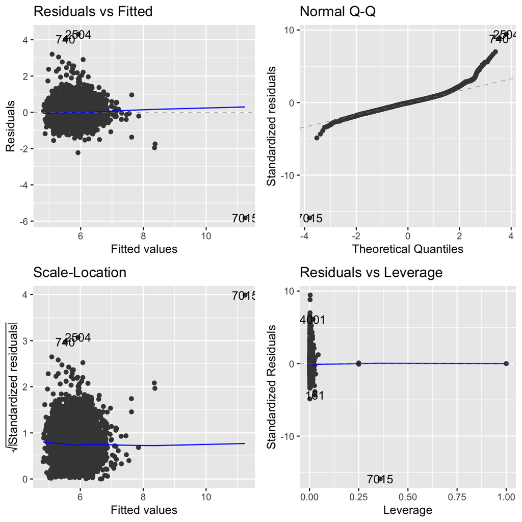

```r
autoplot(model7)
```

# Prediction and Conclusion

```r
newdata=data.frame(prop_type_simplified="Apartment",    log_numberofreview=2.3979,
    review_scores_rating=90, room_type="Private room",
    bathrooms=2, bedrooms=3, beds=4,
    accommodates=6, host_is_superhost=TRUE,
    is_location_exact=TRUE, neighbourhood_simplified = "Bruxelles",
    cancellation_policy="strict_14_with_grace_period")

exp(predict(model7,newdata = newdata, interval="confidence"))
```

```
##   fit lwr upr
## 1 457 435 481
```